# DATA605_Final_Project

Irene Jacob

2021-05-23

## Problem 1.

Using R, generate a random variable X that has 10,000 random uniform numbers from 1 to N, where N can be any number of your choosing greater than or equal to 6. Then generate a random variable Y that has 10,000 random normal numbers with a mean of $\mu=\sigma=(N+1)/2$

```r
set.seed(10)

N <- 25  #i am choosing N as 25
n <- 10000

X <- runif(n, 1, N) #random uniform numbers from 1 to N(here 25)

m <- (N+1)/2


Y = rnorm(n, mean=m, sd=m) #random normal numbers

df <- data.frame(x = X, y = Y)

head(df)
```

|  | x | y |
| --- | --- | --- |
| 1 | 13.179477 | 26.150110 |
| 2 | 8.362444 | 9.420517 |
| 3 | 11.245784 | 14.767172 |
| 4 | 17.634450 | 25.644654 |
| 5 | 3.043263 | 15.406521 |
| 6 | 6.410479 | 7.858382 |

### Probability

Calculate as a minimum the below probabilities a through c. Assume the small letter “x” is estimated as the median of the X variable, and the small letter “y” is estimated as the 1st quartile of the Y variable. Interpret the meaning of all probabilities.

```r
x <- median(X)

y <- quantile(Y, 0.25)

print(paste("median of the X variable",round(x,4),"1st quartile of the Y variable",round(y,4)))
```

```
## [1] "median of the X variable 12.8626 1st quartile of the Y variable 4.2838"
```

#### a. P(X>x | X>y)

```r
#a=X>x
#b=X>y
#P(a|b)=P(ab)/P(b)

b<- length(which(X > y))

ab <- length(which(X > x & X > y))

P <- ab/b

print(paste("The probability is: ",round(P,4)))
```

```
## [1] "The probability is:  0.5802"
```

#### b. P(X>x, Y>y)

```r
P = length(which(X > x & Y > y))/n

print(paste("The probability is: ",round(P,4)))
```

```
## [1] "The probability is:  0.3743"
```

#### c. P(X<x | X>y)

```r
#a=X<x
#b=X>y
#P(a|b)=P(ab)/P(b)

b <- length(which(X > y))

ab <- length(which(X < x & X > y))

P <- ab/b

print(paste("The probability is: ",round(P,4)))
```

```
## [1] "The probability is:  0.4198"
```

#### Investigate whether P(X>x and Y>y)=P(X>x)P(Y>y) by building a table and evaluating the marginal and joint probabilities.

```r
i <- length(which(X < x & Y < y))
j <- length(which(X > x & Y < y))
k <- length(which(X < x & Y > y))
l <- length(which(X > x & Y > y))

tab_df <- matrix(c(i,j,k,l),nrow=2)

rownames(tab_df) <- c('X < x','X > x')
colnames(tab_df) <- c('Y < y','Y > y')

tab_df <- as.table(tab_df)
tab_df
```

```
##       Y < y Y > y
## X < x  1243  3757
## X > x  1257  3743
```

```r
# Marginal
m1 <- margin.table(tab_df,1)[2] / margin.table(tab_df)
m2 <- margin.table(tab_df,2)[2] / margin.table(tab_df)

print(paste("The probability is: ",m1 %*% m2))   #matrix multiplication
```

```
## [1] "The probability is:  0.375"
```

```r
# Joint
joint = tab_df[2,2] / margin.table(tab_df)

print(paste("The probability is: ",joint))
```

```
## [1] "The probability is:  0.3743"
```

The marginal and joint probabilities are almost same that could indicate independancy.

#### Check to see if independence holds by using Fisher’s Exact Test and the Chi Square Test. What is the difference between the two? Which is most appropriate?

```r
df_f_c <- table(X > x, Y > y)

df_f_c
```

```
##
##         FALSE TRUE
##   FALSE  1243 3757
##   TRUE   1257 3743
```

```r
fisher.test(df_f_c)  #Fisher’s Exact Test
```

```
##
##  Fisher's Exact Test for Count Data
##
## data:  df_f_c
## p-value = 0.764
## alternative hypothesis: true odds ratio is not equal to 1
## 95 percent confidence interval:
##  0.898962 1.079670
## sample estimates:
## odds ratio
##  0.9851765
```

```r
chisq.test(df_f_c)   #Chi Square Test
```

```
##
##  Pearson's Chi-squared test with Yates' continuity correction
##
## data:  df_f_c
## X-squared = 0.090133, df = 1, p-value = 0.764
```

*Chi Square Test is used for large datasets(it assumes that the size of the sample is large). Fisher’s Exact Test is used for small samples(when used for large samples the process is very tedious)*

*Fisher’s Exact Test and the Chi Square Test have large p value(>0.05) which indicates that the independence is true.*

## Problem 2.

You are to register for Kaggle.com (free) and compete in the House Prices: Advanced Regression Techniques competition. https://www.kaggle.com/c/house-prices-advanced-regression-techniques . I want you to do the following.

### Descriptive and Inferential Statistics

Provide univariate descriptive statistics and appropriate plots for the training data set. Provide a scatterplot matrix for at least two of the independent variables and the dependent variable. Derive a correlation matrix for any three quantitative variables in the dataset. Test the hypotheses that the correlations between each pairwise set of variables is 0 and provide an 80% confidence interval. Discuss the meaning of your analysis. Would you be worried about familywise error? Why or why not?

```r
t <- read.csv("https://raw.githubusercontent.com/irene908/DATA605/main/train.csv")  #train data
head(t)
```

|  | Id | MSSubClass | MSZoning | LotFrontage | LotArea | Street | Alley | LotShape | LandContour | Utilities | LotConfig | LandSlope | Neighborhood | Condition1 | Condition2 | BldgType | HouseStyle | OverallQual | OverallCond | YearBuilt | YearRemodAdd | RoofStyle | RoofMatl | Exterior1st | Exterior2nd | MasVnrType | MasVnrArea | ExterQual | ExterCond | … |
| --- | --- | --- | --- | --- | --- | --- | --- | --- | --- | --- | --- | --- | --- | --- | --- | --- | --- | --- | --- | --- | --- | --- | --- | --- | --- | --- | --- | --- | --- | --- |
| 1 | 1 | 60 | RL | 65 | 8450 | Pave | NA | Reg | Lvl | AllPub | Inside | Gtl | CollgCr | Norm | Norm | 1Fam | 2Story | 7 | 5 | 2003 | 2003 | Gable | CompShg | VinylSd | VinylSd | BrkFace | 196 | Gd | TA | … |
| 2 | 2 | 20 | RL | 80 | 9600 | Pave | NA | Reg | Lvl | AllPub | FR2 | Gtl | Veenker | Feedr | Norm | 1Fam | 1Story | 6 | 8 | 1976 | 1976 | Gable | CompShg | MetalSd | MetalSd | None | 0 | TA | TA | … |
| 3 | 3 | 60 | RL | 68 | 11250 | Pave | NA | IR1 | Lvl | AllPub | Inside | Gtl | CollgCr | Norm | Norm | 1Fam | 2Story | 7 | 5 | 2001 | 2002 | Gable | CompShg | VinylSd | VinylSd | BrkFace | 162 | Gd | TA | … |
| 4 | 4 | 70 | RL | 60 | 9550 | Pave | NA | IR1 | Lvl | AllPub | Corner | Gtl | Crawfor | Norm | Norm | 1Fam | 2Story | 7 | 5 | 1915 | 1970 | Gable | CompShg | Wd Sdng | Wd Shng | None | 0 | TA | TA | … |
| 5 | 5 | 60 | RL | 84 | 14260 | Pave | NA | IR1 | Lvl | AllPub | FR2 | Gtl | NoRidge | Norm | Norm | 1Fam | 2Story | 8 | 5 | 2000 | 2000 | Gable | CompShg | VinylSd | VinylSd | BrkFace | 350 | Gd | TA | … |
| 6 | 6 | 50 | RL | 85 | 14115 | Pave | NA | IR1 | Lvl | AllPub | Inside | Gtl | Mitchel | Norm | Norm | 1Fam | 1.5Fin | 5 | 5 | 1993 | 1995 | Gable | CompShg | VinylSd | VinylSd | None | 0 | TA | TA | … |

```r
summary(t)
```

```
##        Id           MSSubClass      MSZoning          LotFrontage
##  Min.   :   1.0   Min.   : 20.0   Length:1460        Min.   : 21.00
##  1st Qu.: 365.8   1st Qu.: 20.0   Class :character   1st Qu.: 59.00
##  Median : 730.5   Median : 50.0   Mode  :character   Median : 69.00
##  Mean   : 730.5   Mean   : 56.9                      Mean   : 70.05
##  3rd Qu.:1095.2   3rd Qu.: 70.0                      3rd Qu.: 80.00
##  Max.   :1460.0   Max.   :190.0                      Max.   :313.00
##                                                      NA's   :259
##     LotArea          Street             Alley             LotShape
##  Min.   :  1300   Length:1460        Length:1460        Length:1460
##  1st Qu.:  7554   Class :character   Class :character   Class :character
##  Median :  9478   Mode  :character   Mode  :character   Mode  :character
##  Mean   : 10517
##  3rd Qu.: 11602
##  Max.   :215245
##
##  LandContour         Utilities          LotConfig          LandSlope
##  Length:1460        Length:1460        Length:1460        Length:1460
##  Class :character   Class :character   Class :character   Class :character
##  Mode  :character   Mode  :character   Mode  :character   Mode  :character
##
##
##
##
##  Neighborhood        Condition1         Condition2          BldgType
##  Length:1460        Length:1460        Length:1460        Length:1460
##  Class :character   Class :character   Class :character   Class :character
##  Mode  :character   Mode  :character   Mode  :character   Mode  :character
##
##
##
##
##   HouseStyle         OverallQual      OverallCond      YearBuilt
##  Length:1460        Min.   : 1.000   Min.   :1.000   Min.   :1872
##  Class :character   1st Qu.: 5.000   1st Qu.:5.000   1st Qu.:1954
##  Mode  :character   Median : 6.000   Median :5.000   Median :1973
##                     Mean   : 6.099   Mean   :5.575   Mean   :1971
##                     3rd Qu.: 7.000   3rd Qu.:6.000   3rd Qu.:2000
##                     Max.   :10.000   Max.   :9.000   Max.   :2010
##
```

[output cut: 113 more lines]

```
##  Min.   : 1.000   Min.   :2006   Length:1460        Length:1460
##  1st Qu.: 5.000   1st Qu.:2007   Class :character   Class :character
##  Median : 6.000   Median :2008   Mode  :character   Mode  :character
##  Mean   : 6.322   Mean   :2008
##  3rd Qu.: 8.000   3rd Qu.:2009
##  Max.   :12.000   Max.   :2010
##
##    SalePrice
##  Min.   : 34900
##  1st Qu.:129975
##  Median :163000
##  Mean   :180921
##  3rd Qu.:214000
##  Max.   :755000
##
```

```r
str(t)
```

```
## 'data.frame':    1460 obs. of  81 variables:
##  $ Id           : int  1 2 3 4 5 6 7 8 9 10 ...
##  $ MSSubClass   : int  60 20 60 70 60 50 20 60 50 190 ...
##  $ MSZoning     : chr  "RL" "RL" "RL" "RL" ...
##  $ LotFrontage  : int  65 80 68 60 84 85 75 NA 51 50 ...
##  $ LotArea      : int  8450 9600 11250 9550 14260 14115 10084 10382 6120 7420 ...
##  $ Street       : chr  "Pave" "Pave" "Pave" "Pave" ...
##  $ Alley        : chr  NA NA NA NA ...
##  $ LotShape     : chr  "Reg" "Reg" "IR1" "IR1" ...
##  $ LandContour  : chr  "Lvl" "Lvl" "Lvl" "Lvl" ...
##  $ Utilities    : chr  "AllPub" "AllPub" "AllPub" "AllPub" ...
##  $ LotConfig    : chr  "Inside" "FR2" "Inside" "Corner" ...
##  $ LandSlope    : chr  "Gtl" "Gtl" "Gtl" "Gtl" ...
##  $ Neighborhood : chr  "CollgCr" "Veenker" "CollgCr" "Crawfor" ...
##  $ Condition1   : chr  "Norm" "Feedr" "Norm" "Norm" ...
```

[output cut: 67 more lines]

```r
a <- t$LotArea
describe(a)
```

|  | vars | n | mean | sd | median | trimmed | mad | min | max | range | skew | kurtosis | se |
| --- | --- | --- | --- | --- | --- | --- | --- | --- | --- | --- | --- | --- | --- |
| X1 | 1 | 1460 | 10516.83 | 9981.265 | 9478.5 | 9563.284 | 2962.235 | 1300 | 215245 | 213945 | 12.18262 | 202.2623 | 261.2216 |

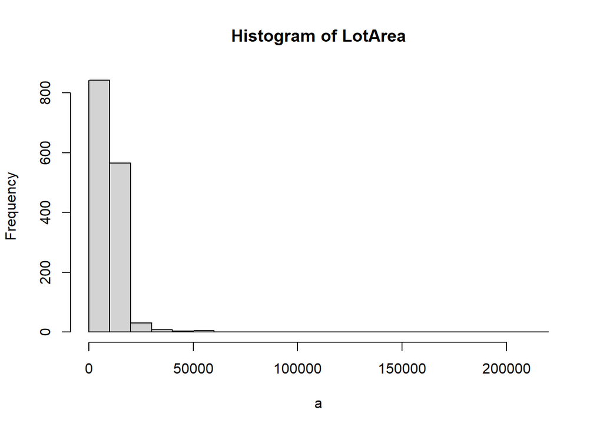

```r
hist(a, breaks=30, main = "Histogram of LotArea")
```

```r
b <- t$GarageArea
describe(b)
```

|  | vars | n | mean | sd | median | trimmed | mad | min | max | range | skew | kurtosis | se |
| --- | --- | --- | --- | --- | --- | --- | --- | --- | --- | --- | --- | --- | --- |
| X1 | 1 | 1460 | 472.9801 | 213.8048 | 480 | 469.8082 | 177.912 | 0 | 1418 | 1418 | 0.1796113 | 0.9044687 | 5.595528 |

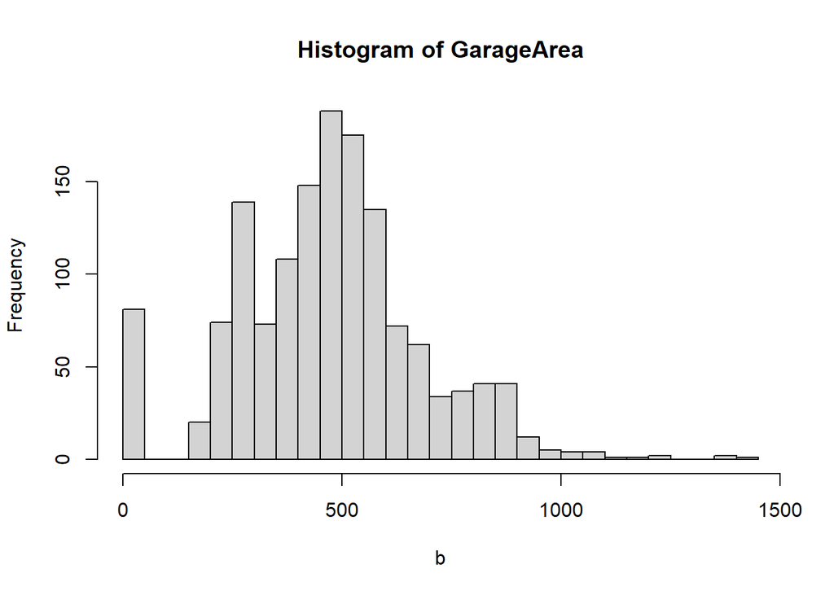

```r
hist(b, breaks=30, main = "Histogram of GarageArea")
```

```r
c <- t$SalePrice
describe(c)
```

|  | vars | n | mean | sd | median | trimmed | mad | min | max | range | skew | kurtosis | se |
| --- | --- | --- | --- | --- | --- | --- | --- | --- | --- | --- | --- | --- | --- |
| X1 | 1 | 1460 | 180921.2 | 79442.5 | 163000 | 170783.3 | 56338.8 | 34900 | 755000 | 720100 | 1.879009 | 6.496789 | 2079.105 |

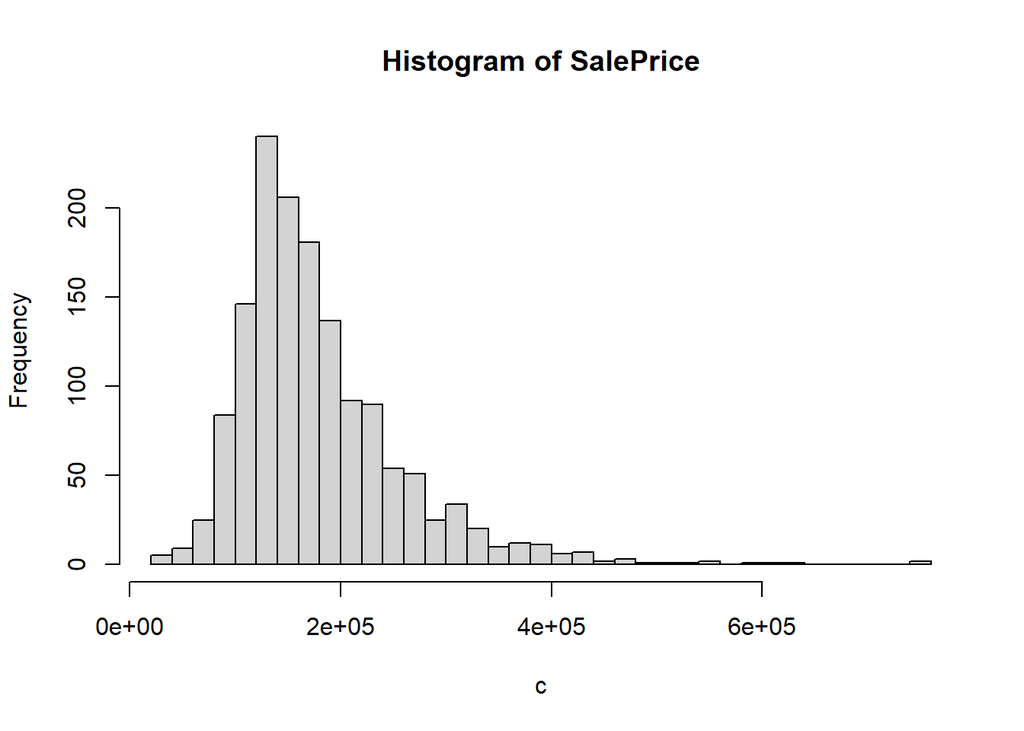

```r
hist(c, breaks=30, main = "Histogram of SalePrice")
```

There are 1460 observations in LotArea, GarageArea and SalePrice. The distribution of these observations are all right skewed with few outliers.

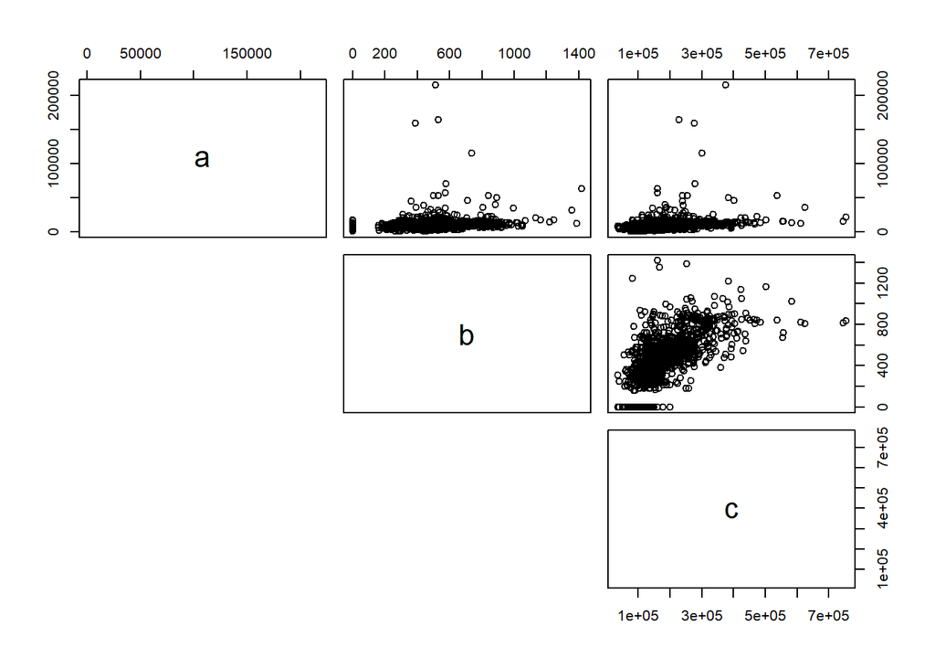

```r
#scatterplot matrix for at least two of the independent variables and the dependent variable.
pairs(~ a + b + c,lower.panel=NULL, data = t)
```

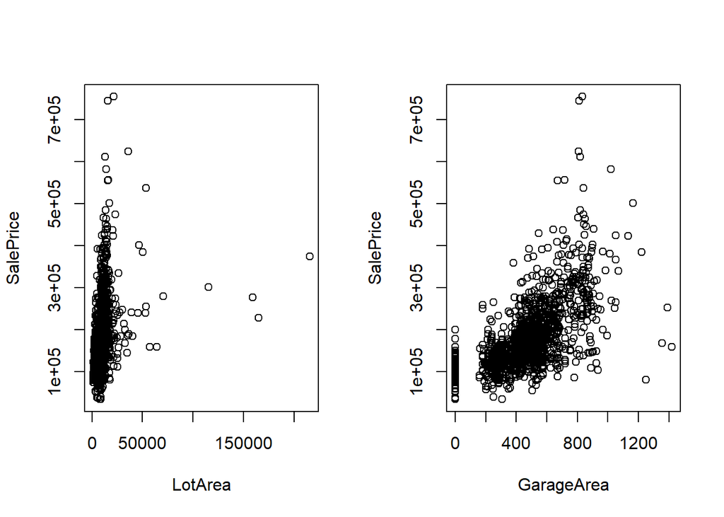

```r
par(mfrow=c(1,2))
plot(a, c, xlab="LotArea", ylab="SalePrice")
plot(b, c, xlab="GarageArea", ylab="SalePrice")
```

There not much correlation between LotArea and the SalePrice. There is some correlation between GarageArea and the SalePrice.

```r
#correlation matrix
df_cor <- t[c("LotArea", "GarageArea", "SalePrice")]
mat_cor <- cor(df_cor, use = "pairwise.complete.obs")
print(mat_cor)
```

```
##              LotArea GarageArea SalePrice
## LotArea    1.0000000  0.1804028 0.2638434
## GarageArea 0.1804028  1.0000000 0.6234314
## SalePrice  0.2638434  0.6234314 1.0000000
```

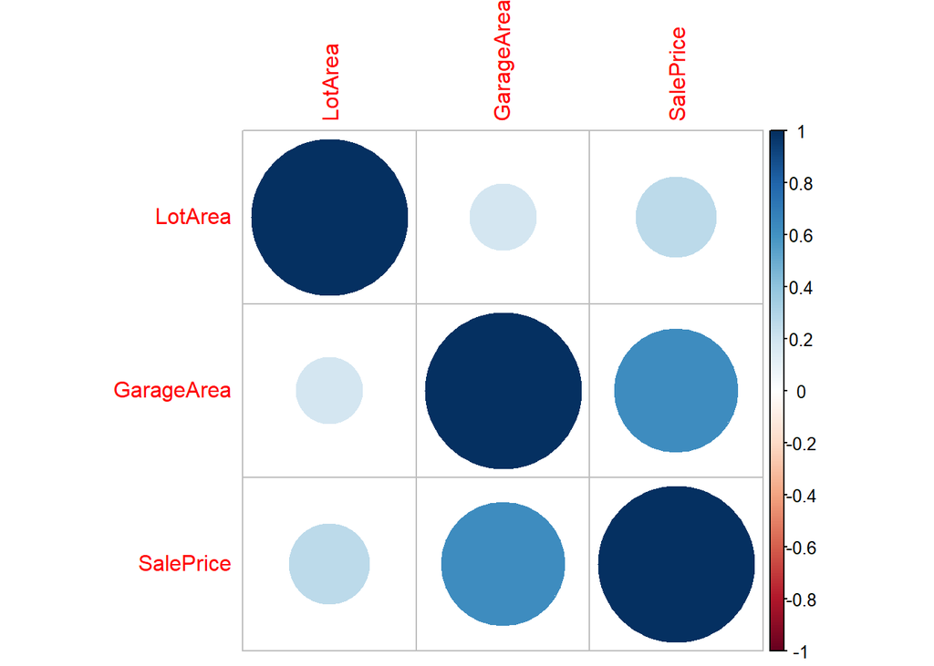

```r
#t %>% select(LotArea, GarageArea, SalePrice ) %>% cor(use="pairwise.complete.obs") %>% corrplot()
corrplot(mat_cor,method="circle")
```

The high correlation between GarageArea and the SalePrice is very clear here.

```r
#Test the hypotheses that the correlations between each pairwise set of variables is 0 and provide an 80% confidence interval.

#LotArea and GarageArea
cor.test(a, b, method = 'pearson', conf.level = 0.80)
```

```
##
##  Pearson's product-moment correlation
##
## data:  a and b
## t = 7.0034, df = 1458, p-value = 3.803e-12
## alternative hypothesis: true correlation is not equal to 0
## 80 percent confidence interval:
##  0.1477356 0.2126767
## sample estimates:
##       cor
## 0.1804028
```

```r
#LotArea and SalePrice
cor.test(a, c, method = 'pearson', conf.level = 0.80)
```

```
##
##  Pearson's product-moment correlation
##
## data:  a and c
## t = 10.445, df = 1458, p-value < 2.2e-16
## alternative hypothesis: true correlation is not equal to 0
## 80 percent confidence interval:
##  0.2323391 0.2947946
## sample estimates:
##       cor
## 0.2638434
```

```r
#GarageArea and SalePrice
cor.test(b, c, method = 'pearson', conf.level = 0.80)
```

```
##
##  Pearson's product-moment correlation
##
## data:  b and c
## t = 30.446, df = 1458, p-value < 2.2e-16
## alternative hypothesis: true correlation is not equal to 0
## 80 percent confidence interval:
##  0.6024756 0.6435283
## sample estimates:
##       cor
## 0.6234314
```

**Discuss the meaning of your analysis. Would you be worried about familywise error? Why or why not?**

I would not be worried about the familywise error as the p-values are almost 0 in all the cases.

### Linear Algebra and Correlation

Invert your correlation matrix from above. (This is known as the precision matrix and contains variance inflation factors on the diagonal.) Multiply the correlation matrix by the precision matrix, and then multiply the precision matrix by the correlation matrix. Conduct LU decomposition on the matrix.

```r
#precision matrix
mat_pre <- solve(mat_cor)
mat_pre
```

```
##                LotArea  GarageArea  SalePrice
## LotArea     1.07530074 -0.02799273 -0.2662594
## GarageArea -0.02799273  1.63649778 -1.0128585
## SalePrice  -0.26625940 -1.01285847  1.7016986
```

```r
mat_cor #correlation matrix
```

```
##              LotArea GarageArea SalePrice
## LotArea    1.0000000  0.1804028 0.2638434
## GarageArea 0.1804028  1.0000000 0.6234314
## SalePrice  0.2638434  0.6234314 1.0000000
```

```r
round(mat_cor %*% mat_pre)  #Multiply the correlation matrix by the precision matrix
```

```
##            LotArea GarageArea SalePrice
## LotArea          1          0         0
## GarageArea       0          1         0
## SalePrice        0          0         1
```

```r
round(mat_pre %*% mat_cor)  #multiply the precision matrix by the correlation matrix
```

```
##            LotArea GarageArea SalePrice
## LotArea          1          0         0
## GarageArea       0          1         0
## SalePrice        0          0         1
```

```r
#LU decomposition on the correlation matrix
cor_lu <- lu.decomposition(mat_cor)
#cor_lu_expand <- expand(cor_lu)

L <- cor_lu$L
U <- cor_lu$U

L #Lower Triangle
```

```
##           [,1]      [,2] [,3]
## [1,] 1.0000000 0.0000000    0
## [2,] 0.1804028 1.0000000    0
## [3,] 0.2638434 0.5952044    1
```

```r
U #Upper Triangle
```

```
##      [,1]      [,2]      [,3]
## [1,]    1 0.1804028 0.2638434
## [2,]    0 0.9674548 0.5758334
## [3,]    0 0.0000000 0.5876481
```

```r
L %*% U
```

```
##           [,1]      [,2]      [,3]
## [1,] 1.0000000 0.1804028 0.2638434
## [2,] 0.1804028 1.0000000 0.6234314
## [3,] 0.2638434 0.6234314 1.0000000
```

```r
#LU decomposition on the precision matrix
pre_lu <- lu.decomposition(mat_pre)


p_L <- pre_lu$L
p_U <- pre_lu$U

p_L #Lower Triangle
```

```
##             [,1]       [,2] [,3]
## [1,]  1.00000000  0.0000000    0
## [2,] -0.02603247  1.0000000    0
## [3,] -0.24761389 -0.6234314    1
```

```r
p_U #Upper Triangle
```

```
##          [,1]        [,2]       [,3]
## [1,] 1.075301 -0.02799273 -0.2662594
## [2,] 0.000000  1.63576906 -1.0197899
## [3,] 0.000000  0.00000000  1.0000000
```

```r
p_L %*% p_U
```

```
##             [,1]        [,2]       [,3]
## [1,]  1.07530074 -0.02799273 -0.2662594
## [2,] -0.02799273  1.63649778 -1.0128585
## [3,] -0.26625940 -1.01285847  1.7016986
```

In both correlation and precision matrix the multiplication of L and U matrix resulted in the original correlation and precision matrix.

### Calculus-Based Probability & Statistics

Many times, it makes sense to fit a closed form distribution to data. Select a variable in the Kaggle.com training dataset that is skewed to the right, shift it so that the minimum value is absolutely above zero if necessary. Then load the MASS package and run fitdistr to fit an exponential probability density function. (See https://stat.ethz.ch/R-manual/R-devel/library/MASS/html/fitdistr.html ). Find the optimal value of $\lambda$ for this distribution, and then take 1000 samples from this exponential distribution using this value (e.g., rexp(1000, $\lambda$)). Plot a histogram and compare it with a histogram of your original variable. Using the exponential pdf, find the 5th and 95th percentiles using the cumulative distribution function (CDF). Also generate a 95% confidence interval from the empirical data, assuming normality. Finally, provide the empirical 5th percentile and 95th percentile of the data. Discuss.

```r
#selecting LotArea
la<- t$LotArea
min(la)
```

```
## [1] 1300
```

```r
skim(t$LotArea)
```

Data summary

| Name | t$LotArea |
| --- | --- |
| Number of rows | 1460 |
| Number of columns | 1 |
| _______________________ |  |
| Column type frequency: |  |
| numeric | 1 |
| ________________________ |  |
| Group variables | None |

**Variable type: numeric**

| skim_variable | n_missing | complete_rate | mean | sd | p0 | p25 | p50 | p75 | p100 | hist |
| --- | --- | --- | --- | --- | --- | --- | --- | --- | --- | --- |
| data | 0 | 1 | 10516.83 | 9981.26 | 1300 | 7553.5 | 9478.5 | 11601.5 | 215245 | ▇▁▁▁▁ |

```r
#shift it so that the minimum value is absolutely above zero
t_la_shift <- t %>% mutate(LotArea = LotArea - 1300)
skim(t_la_shift$LotArea)
```

Data summary

| Name | t_la_shift$LotArea |
| --- | --- |
| Number of rows | 1460 |
| Number of columns | 1 |
| _______________________ |  |
| Column type frequency: |  |
| numeric | 1 |
| ________________________ |  |
| Group variables | None |

**Variable type: numeric**

| skim_variable | n_missing | complete_rate | mean | sd | p0 | p25 | p50 | p75 | p100 | hist |
| --- | --- | --- | --- | --- | --- | --- | --- | --- | --- | --- |
| data | 0 | 1 | 9216.83 | 9981.26 | 0 | 6253.5 | 8178.5 | 10301.5 | 213945 | ▇▁▁▁▁ |

```r
#run fitdistr to fit an exponential probability density function.
la_exp <- fitdistr(t_la_shift$LotArea, densfun = "exponential")
la_exp
```

```
##        rate
##   1.084972e-04
##  (2.839501e-06)
```

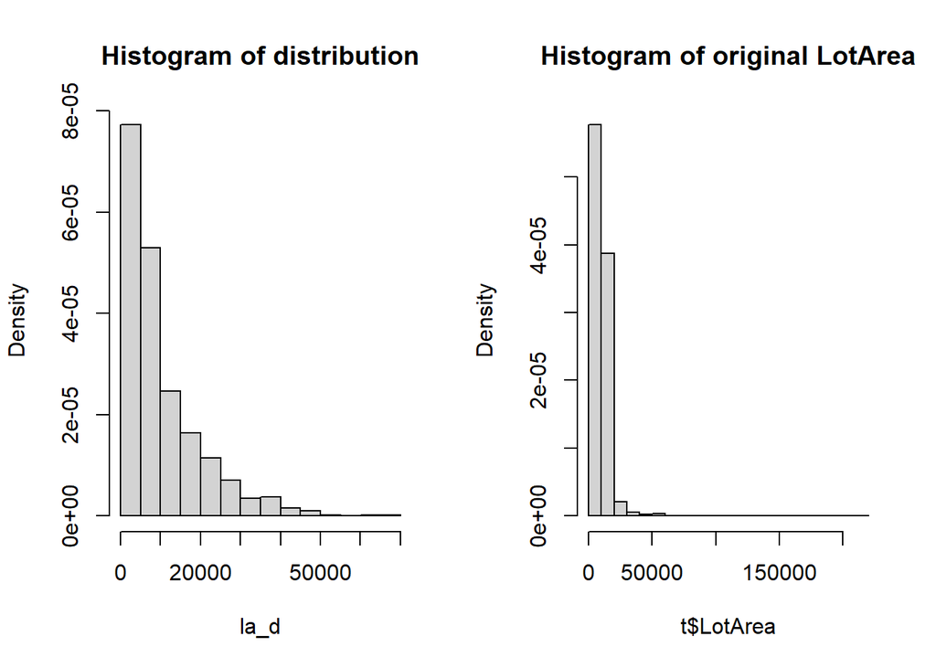

```r
#Find the optimal value of $\lambda$ for this distribution, and then take 1000 samples from this exponential distribution using this value
la_d <- rexp(1000, la_exp$estimate)

#Plot a histogram and compare it with a histogram of your original variable.
par(mfrow=c(1,2))
hist(la_d, freq = FALSE, breaks = 20, main = "Histogram of distribution")
hist(t$LotArea, freq = FALSE, breaks = 20, main = "Histogram of original LotArea")
```

The original data’s histogram is heavily right skewed whereas the distribution’s histogram is less right skewed.

```r
#5th and 95th percentiles using the cumulative distribution function (CDF)
quantile(la_d, probs = c(0.05, 0.95))
```

```
##         5%        95%
##   398.6687 30378.5826
```

```r
#generate a 95% confidence interval from the empirical data, assuming normality
CI(la_d, ci = 0.95)
```

```
##     upper      mean     lower
## 10569.824  9958.153  9346.483
```

```r
#empirical 5th percentile and 95th percentile of the data
la_o <- sample(t$LotArea,  1000, replace=TRUE, prob=NULL)
quantile(la_o, c(.05, .95))
```

```
##       5%      95%
##  3735.00 17500.15
```

### Modeling

Build some type of multiple regression model and submit your model to the competition board. Provide your complete model summary and results with analysis. Report your Kaggle.com user name and score.

```r
train <- read.csv("https://raw.githubusercontent.com/irene908/DATA605/main/train.csv")  #train data(loaded again)
test <- read.csv("https://raw.githubusercontent.com/irene908/DATA605/main/test.csv") #test data
```

```r
#filter out the required attributes from the train set
t <- subset(train, select=c(MSSubClass,MSZoning,LotArea,LotShape,LotConfig,Neighborhood,BldgType,HouseStyle,OverallQual,OverallCond,YearBuilt,YearRemodAdd,RoofStyle,MasVnrType,MasVnrArea,ExterQual,BsmtQual,BsmtCond,BsmtExposure,TotalBsmtSF,Heating,HeatingQC,Electrical,X1stFlrSF,GrLivArea,TotRmsAbvGrd,Functional,GarageCars,GarageArea,PavedDrive,WoodDeckSF,OpenPorchSF,MiscVal,MoSold,YrSold,SaleType,SaleCondition,SalePrice))

#handle missing data
t<- na.omit(t)
```

**Multiple Regression**

```r
t.lm <- lm(SalePrice ~ MSSubClass + MSZoning + LotArea + LotShape + LotConfig + Neighborhood + BldgType + HouseStyle + OverallQual + OverallCond + YearBuilt + YearRemodAdd + RoofStyle + + MasVnrType + MasVnrArea + ExterQual + BsmtQual + BsmtCond + BsmtExposure + TotalBsmtSF + Heating + HeatingQC + Electrical + X1stFlrSF + GrLivArea + TotRmsAbvGrd + Functional + GarageCars + GarageArea + PavedDrive + WoodDeckSF + OpenPorchSF + MiscVal + MoSold + YrSold + SaleType + SaleCondition, data = t)


summary(t.lm)
```

```
##
## Call:
## lm(formula = SalePrice ~ MSSubClass + MSZoning + LotArea + LotShape +
##     LotConfig + Neighborhood + BldgType + HouseStyle + OverallQual +
##     OverallCond + YearBuilt + YearRemodAdd + RoofStyle + +MasVnrType +
##     MasVnrArea + ExterQual + BsmtQual + BsmtCond + BsmtExposure +
##     TotalBsmtSF + Heating + HeatingQC + Electrical + X1stFlrSF +
##     GrLivArea + TotRmsAbvGrd + Functional + GarageCars + GarageArea +
##     PavedDrive + WoodDeckSF + OpenPorchSF + MiscVal + MoSold +
##     YrSold + SaleType + SaleCondition, data = t)
##
## Residuals:
##     Min      1Q  Median      3Q     Max
## -358632  -12522      63   11080  243508
##
## Coefficients:
##                        Estimate Std. Error t value Pr(>|t|)
## (Intercept)          -2.367e+05  1.316e+06  -0.180 0.857302
## MSSubClass           -1.733e+02  1.029e+02  -1.684 0.092509 .
## MSZoningFV            3.661e+04  1.495e+04   2.449 0.014440 *
## MSZoningRH            2.544e+04  1.492e+04   1.706 0.088316 .
## MSZoningRL            2.746e+04  1.259e+04   2.180 0.029442 *
## MSZoningRM            2.279e+04  1.181e+04   1.929 0.053929 .
## LotArea               4.521e-01  1.029e-01   4.395 1.20e-05 ***
## LotShapeIR2           6.859e+03  5.286e+03   1.298 0.194646
## LotShapeIR3          -3.753e+04  1.064e+04  -3.527 0.000435 ***
## LotShapeReg           1.257e+03  2.019e+03   0.623 0.533561
## LotConfigCulDSac      9.205e+03  4.022e+03   2.288 0.022270 *
## LotConfigFR2         -1.142e+04  5.087e+03  -2.246 0.024881 *
## LotConfigFR3         -1.357e+04  1.561e+04  -0.869 0.384935
## LotConfigInside       1.088e+03  2.191e+03   0.497 0.619542
## NeighborhoodBlueste   1.290e+04  2.371e+04   0.544 0.586569
## NeighborhoodBrDale    1.826e+04  1.352e+04   1.350 0.177218
## NeighborhoodBrkSide   3.364e+03  1.148e+04   0.293 0.769538
## NeighborhoodClearCr   3.012e+02  1.134e+04   0.027 0.978821
## NeighborhoodCollgCr   2.405e+02  8.984e+03   0.027 0.978649
## NeighborhoodCrawfor   2.403e+04  1.041e+04   2.308 0.021156 *
## NeighborhoodEdwards  -1.653e+04  9.915e+03  -1.667 0.095768 .
## NeighborhoodGilbert  -3.055e+03  9.645e+03  -0.317 0.751501
## NeighborhoodIDOTRR    3.493e+02  1.325e+04   0.026 0.978973
```

[output cut: 85 more lines]

```
## SaleTypeCWD           7.400e+03  1.637e+04   0.452 0.651328
## SaleTypeNew           2.554e+04  1.939e+04   1.317 0.188020
## SaleTypeOth           1.674e+04  1.853e+04   0.903 0.366553
## SaleTypeWD            2.864e+03  5.289e+03   0.541 0.588258
## SaleConditionAdjLand  2.410e+04  1.932e+04   1.247 0.212628
## SaleConditionAlloca   1.680e+04  1.206e+04   1.393 0.163977
## SaleConditionFamily  -4.631e+03  7.727e+03  -0.599 0.549074
## SaleConditionNormal   5.316e+03  3.583e+03   1.484 0.138091
## SaleConditionPartial -1.140e+04  1.867e+04  -0.611 0.541395
## ---
## Signif. codes:  0 '***' 0.001 '**' 0.01 '*' 0.05 '.' 0.1 ' ' 1
##
## Residual standard error: 29830 on 1296 degrees of freedom
## Multiple R-squared:  0.8701, Adjusted R-squared:  0.8585
## F-statistic: 74.85 on 116 and 1296 DF,  p-value: < 2.2e-16
```

```r
#filter out the required attributes from the test set
test.filter <- subset(test, select=c(MSSubClass,MSZoning,LotArea,LotShape,LotConfig,Neighborhood,BldgType,HouseStyle,OverallQual,OverallCond,YearBuilt,YearRemodAdd,RoofStyle,MasVnrType,MasVnrArea,ExterQual,BsmtQual,BsmtCond,BsmtExposure,TotalBsmtSF,Heating,HeatingQC,Electrical,X1stFlrSF,GrLivArea,TotRmsAbvGrd,Functional,GarageCars,GarageArea,PavedDrive,WoodDeckSF,OpenPorchSF,MiscVal,MoSold,YrSold,SaleType,SaleCondition))

#handle missing data
test.filter <- na.omit(test.filter)
```

```r
pred <- predict(t.lm, test.filter)

#summary of prediction
summary(pred)
```

```
##    Min. 1st Qu.  Median    Mean 3rd Qu.    Max.
##   17955  129952  163046  180759  215478  536496
```

```r
#summary of train set SalePrice
summary(t$SalePrice)
```

```
##    Min. 1st Qu.  Median    Mean 3rd Qu.    Max.
##   34900  131500  164700  182579  215000  755000
```

From the summary statistics the 1st Qu,Median,Mean and 3rd Qu looks good.

```r
#adding id to the predicted data
df_final <- as.data.frame(cbind(test$Id, pred))
colnames(df_final) = c("Id", "SalePrice")

head(df_final)
```

|  | Id | SalePrice |
| --- | --- | --- |
| 1 | 1461 | 112876.6 |
| 2 | 1462 | 146630.6 |
| 3 | 1463 | 162326.1 |
| 4 | 1464 | 177893.1 |
| 5 | 1465 | 227651.7 |
| 6 | 1466 | 172616.3 |

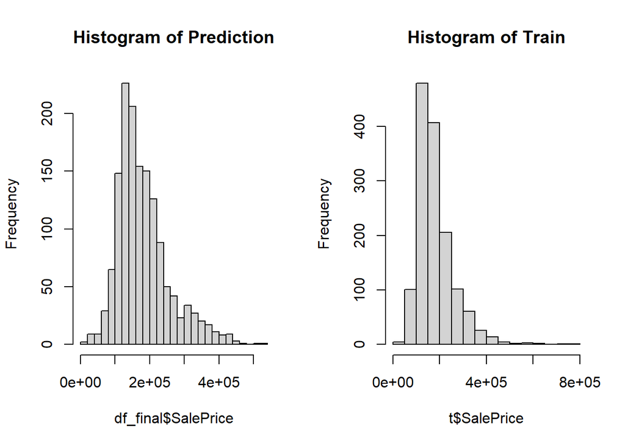

```r
#Histograms of predicted and Train data
par(mfrow=c(1,2))
hist(df_final$SalePrice, breaks=20, main = 'Histogram of Prediction')
hist(t$SalePrice, breaks=20, main = 'Histogram of Train')
```

```r
#writing to csv file for kaggle submission
write.csv(df_final, file="IJacob_FinalProject_Kaggle.csv", row.names = FALSE)
```

**Kaggle Submission**

Username: Irene Jacob 908

Score: 0.52008

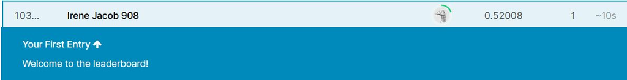

```r
knitr::include_graphics("C://kaggle_1.JPG")
```

[figure not shown]

```r
knitr::include_graphics("C://kaggle_2.JPG")
```